# Credit Card Users Churn Prediction

## Observation

- After encoding there are 29 columns each in the train, val, and test datasets.

## Model Building

### Model evaluation criterion

**Which metric to optimize?**

**Let's define a function to output different metrics (including recall) on the train and test set and a function to show confusion matrix so that we do not have to use the same code repetitively while evaluating models.**

```python
# defining a function to compute different metrics to check performance of a classification model built using sklearn
def model_performance_classification_sklearn(model, predictors, target):
    """
    Function to compute different metrics to check classification model performance

    model: classifier
    predictors: independent variables
    target: dependent variable
    """

    # predicting using the independent variables
    pred = model.predict(predictors)

    acc = accuracy_score(target, pred)  # to compute Accuracy
    recall = recall_score(target, pred)  # to compute Recall
    precision = precision_score(target, pred)  # to compute Precision
    f1 = f1_score(target, pred)  # to compute F1-score

    # creating a dataframe of metrics
    df_perf = pd.DataFrame(
        {
            "Accuracy": acc,
            "Recall": recall,
            "Precision": precision,
            "F1": f1

        },
        index=[0],
    )

    return df_perf
```

```python
def confusion_matrix_sklearn(model, predictors, target):
    """
    To plot the confusion_matrix with percentages

    model: classifier
    predictors: independent variables
    target: dependent variable
    """
    y_pred = model.predict(predictors)
    cm = confusion_matrix(target, y_pred)
    labels = np.asarray(
        [
            ["{0:0.0f}".format(item) + "\n{0:.2%}".format(item / cm.flatten().sum())]
            for item in cm.flatten()
        ]
    ).reshape(2, 2)

    plt.figure(figsize=(6, 4))
    sns.heatmap(cm, annot=labels, fmt="")
    plt.ylabel("True label")
    plt.xlabel("Predicted label")
```

## Model Building with original data

#### Model 1 - Logistics Regression

```python
lr = LogisticRegression(random_state=1)
lr.fit(X_train, Y_train)
```

```
LogisticRegression(random_state=1)
```

```
array([0.97156863, 0.95294118, 0.96078431, 0.96372549, 0.96761531])
```

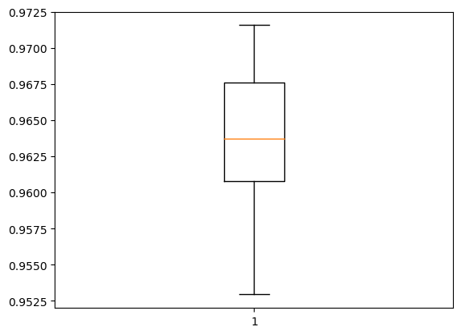

```python
scoring = "recall"
kfold = StratifiedKFold(
    n_splits=5, shuffle=True, random_state=1
)  # Setting number of splits equal to 5
cv_result_bfr = cross_val_score(
    estimator=lr, X=X_train, y=Y_train, scoring=scoring, cv=kfold
)

display(cv_result_bfr)
# Plotting boxplots for CV scores of model defined above
plt.boxplot(cv_result_bfr)
plt.show()
```

## Observations

- Performance on training set varies between ~0.953 to ~0.972 recall.
- Let's check the performance on validation data.

```python
# Calculating different metrics on train set
log_reg_model_train_perf = model_performance_classification_sklearn(
    lr, X_train, Y_train
)
print("Training performance:")
log_reg_model_train_perf
```

```
Training performance:
```

|  | Accuracy | Recall | Precision | F1 |
| --- | --- | --- | --- | --- |
| 0 | 0.886 | 0.976 | 0.897 | 0.935 |

```python
# Calculating different metrics on validation set
log_reg_model_val_perf = model_performance_classification_sklearn(lr, X_val, Y_val)
print("Validation performance:")
log_reg_model_val_perf
```

```
Validation performance:
```

|  | Accuracy | Recall | Precision | F1 |
| --- | --- | --- | --- | --- |
| 0 | 0.874 | 0.977 | 0.884 | 0.928 |

```python
# Calculating different metrics on test set
log_reg_model_test_perf = model_performance_classification_sklearn(lr, X_test, Y_test)
print("Test performance:")
log_reg_model_test_perf
```

```
Test performance:
```

|  | Accuracy | Recall | Precision | F1 |
| --- | --- | --- | --- | --- |
| 0 | 0.883 | 0.982 | 0.890 | 0.934 |

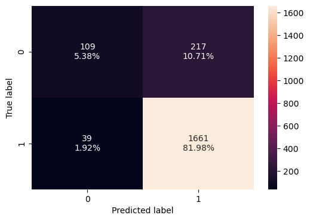

```python
# creating confusion matrix
confusion_matrix_sklearn(lr, X_val, Y_val)
```

## Observation

- Logistic Regression has given a similar performance on test, training and validation sets.
- Recall is very high in both the training and validation sets.
- Recall is ~ 98% in test set.

#### Model 2 - Decision Tree

```
Training performance:
    Accuracy  Recall  Precision    F1
0     1.000   1.000      1.000 1.000
Validation performance:
    Accuracy  Recall  Precision    F1
0     0.930   0.963      0.955 0.959
Testing performance:
    Accuracy  Recall  Precision    F1
0     0.936   0.964      0.960 0.962
```

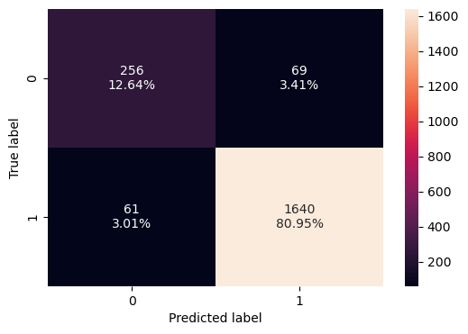

```python
#Fitting the model
d_tree = DecisionTreeClassifier(random_state=1)
d_tree.fit(X_train,Y_train)

#Calculating different metrics
dtree_model_train_perf=model_performance_classification_sklearn(d_tree,X_train,Y_train)
print("Training performance:\n",dtree_model_train_perf)
dtree_model_val_perf=model_performance_classification_sklearn(d_tree,X_val,Y_val)
print("Validation performance:\n",dtree_model_val_perf)
dtree_model_test_perf=model_performance_classification_sklearn(d_tree,X_test,Y_test)
print("Testing performance:\n",dtree_model_test_perf)
#Creating confusion matrix
confusion_matrix_sklearn(d_tree, X_test, Y_test)
```

## Observation

- The decision tree is performing well in training, validation and testing dataset for all the metrics.
- Recall is very high in the test, training and validation sets.
- The test recall is at ~ 96%.

#### Model 3 - Bagging Classifier

```
Training performance:
    Accuracy  Recall  Precision    F1
0     0.997   0.998      0.999 0.998
Validation performance:
    Accuracy  Recall  Precision    F1
0     0.953   0.979      0.965 0.972
Testing performance:
    Accuracy  Recall  Precision    F1
0     0.952   0.976      0.967 0.971
```

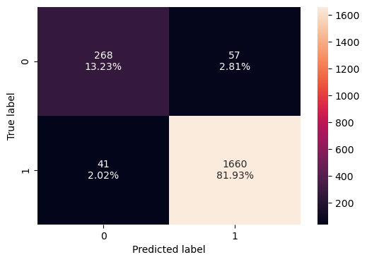

```python
#Fitting the model
bagging_classifier = BaggingClassifier(random_state=1)
bagging_classifier.fit(X_train,Y_train)

#Calculating different metrics
bagging_classifier_model_train_perf=model_performance_classification_sklearn(bagging_classifier,X_train,Y_train)
print("Training performance:\n",bagging_classifier_model_train_perf)
bagging_classifier_model_val_perf=model_performance_classification_sklearn(bagging_classifier,X_val,Y_val)
print("Validation performance:\n",bagging_classifier_model_val_perf)
bagging_classifier_model_test_perf=model_performance_classification_sklearn(bagging_classifier,X_test,Y_test)
print("Testing performance:\n",bagging_classifier_model_test_perf)
#Creating confusion matrix
confusion_matrix_sklearn(bagging_classifier, X_test, Y_test)
```

## Observation

- The bagging classifier is performing well in training, validation and testing dataset for all the metrics and similar to Logistics regression.
- Recall is very high in the test, training and validation sets.
- The test recall is at ~ 97%.

#### Model 4 - Random Forest

```
Training performance:
    Accuracy  Recall  Precision    F1
0     1.000   1.000      1.000 1.000
Validation performance:
    Accuracy  Recall  Precision    F1
0     0.947   0.985      0.954 0.969
Testing performance:
    Accuracy  Recall  Precision    F1
0     0.950   0.990      0.952 0.971
```

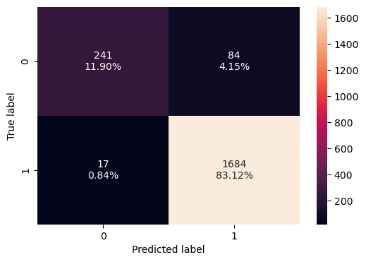

```python
#Fitting the model
rf_estimator = RandomForestClassifier(random_state=1)
rf_estimator.fit(X_train,Y_train)

#Calculating different metrics
rf_estimator_model_train_perf=model_performance_classification_sklearn(rf_estimator,X_train,Y_train)
print("Training performance:\n",rf_estimator_model_train_perf)
rf_estimator_model_val_perf=model_performance_classification_sklearn(rf_estimator,X_val,Y_val)
print("Validation performance:\n",rf_estimator_model_val_perf)
rf_estimator_model_test_perf=model_performance_classification_sklearn(rf_estimator,X_test,Y_test)
print("Testing performance:\n",rf_estimator_model_test_perf)

#Creating confusion matrix
confusion_matrix_sklearn(rf_estimator, X_test, Y_test)
```

## Observation

- Random Forest is performing well in training, validation and testing dataset for all the metrics.
- Recall is very high in the test, training and validation sets.
- The test recall is at ~ 99%.

#### Model 5 - AdaBoost Classifier

```
   Accuracy  Recall  Precision    F1
0     0.961   0.983      0.972 0.977
   Accuracy  Recall  Precision    F1
0     0.955   0.982      0.965 0.973
   Accuracy  Recall  Precision    F1
0     0.957   0.980      0.969 0.975
```

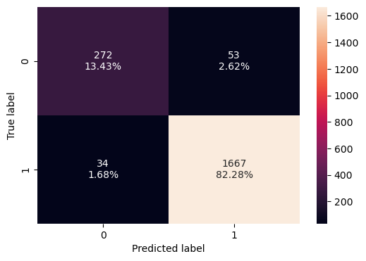

```python
#Fitting the model
ab_classifier = AdaBoostClassifier(random_state=1)
ab_classifier.fit(X_train,Y_train)

#Calculating different metrics
ab_classifier_model_train_perf=model_performance_classification_sklearn(ab_classifier,X_train,Y_train)
print(ab_classifier_model_train_perf)
ab_classifier_model_val_perf=model_performance_classification_sklearn(ab_classifier,X_val,Y_val)
print(ab_classifier_model_val_perf)
ab_classifier_model_test_perf=model_performance_classification_sklearn(ab_classifier,X_test,Y_test)
print(ab_classifier_model_test_perf)

#Creating confusion matrix
confusion_matrix_sklearn(ab_classifier,X_test,Y_test)
```

## Observation

- AdaBoost Classifier is performing well in training, validation and testing dataset for all the metrics.
- Recall is very high in the test, training and validation sets.
- The test recall is at ~ 98%.

#### Model 6 - Gradient Boosting Classifier

```
Training performance:
    Accuracy  Recall  Precision    F1
0     0.978   0.992      0.982 0.987
Validation performance:
    Accuracy  Recall  Precision    F1
0     0.961   0.989      0.966 0.977
Testing performance:
    Accuracy  Recall  Precision    F1
0     0.965   0.991      0.968 0.979
```

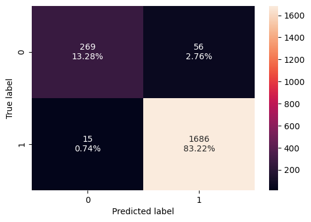

```python
#Fitting the model
gb_classifier = GradientBoostingClassifier(random_state=1)
gb_classifier.fit(X_train,Y_train)

#Calculating different metrics
gb_classifier_model_train_perf=model_performance_classification_sklearn(gb_classifier,X_train,Y_train)
print("Training performance:\n",gb_classifier_model_train_perf)
gb_classifier_model_val_perf=model_performance_classification_sklearn(gb_classifier,X_val,Y_val)
print("Validation performance:\n",gb_classifier_model_val_perf)
gb_classifier_model_test_perf=model_performance_classification_sklearn(gb_classifier,X_test,Y_test)
print("Testing performance:\n",gb_classifier_model_test_perf)

#Creating confusion matrix
confusion_matrix_sklearn(gb_classifier,X_test,Y_test)
```

## Model Building with Oversampled data

```python
print("Before Oversampling, counts of label 'Yes': {}".format(sum(Y_train == 1)))
print("Before Oversampling, counts of label 'No': {} \n".format(sum(Y_train == 0)))

sm = SMOTE(
    sampling_strategy=1, k_neighbors=5, random_state=1
)  # Synthetic Minority Over Sampling Technique
X_train_over, Y_train_over = sm.fit_resample(X_train, Y_train)


print("After Oversampling, counts of label 'Yes': {}".format(sum(Y_train_over == 1)))
print("After Oversampling, counts of label 'No': {} \n".format(sum(Y_train_over == 0)))


print("After Oversampling, the shape of train_X: {}".format(Y_train_over.shape))
print("After Oversampling, the shape of train_Y: {} \n".format(Y_train_over.shape))
```

```
Before Oversampling, counts of label 'Yes': 5099
Before Oversampling, counts of label 'No': 976

After Oversampling, counts of label 'Yes': 5099
After Oversampling, counts of label 'No': 5099

After Oversampling, the shape of train_X: (10198,)
After Oversampling, the shape of train_Y: (10198,)
```

#### Model 1 - Logistic Regression on oversampled data

```python
log_reg_over = LogisticRegression(random_state=1)

# Training the basic logistic regression model with training set
log_reg_over.fit(X_train_over, Y_train_over)
```

```
LogisticRegression(random_state=1)
```

#### Let's check the model performance on train and validation sets

```python
# Calculating different metrics on train set
log_reg_over_train_perf = model_performance_classification_sklearn(log_reg_over, X_train_over, Y_train_over)
print("Training performance:")
log_reg_over_train_perf
```

```
Training performance:
```

|  | Accuracy | Recall | Precision | F1 |
| --- | --- | --- | --- | --- |
| 0 | 0.828 | 0.841 | 0.820 | 0.831 |

```python
# Calculating different metrics on validation set
log_reg_over_val_perf = model_performance_classification_sklearn(log_reg_over, X_val, Y_val)
print("Validation performance:")
log_reg_over_val_perf
```

```
Validation performance:
```

|  | Accuracy | Recall | Precision | F1 |
| --- | --- | --- | --- | --- |
| 0 | 0.835 | 0.852 | 0.946 | 0.897 |

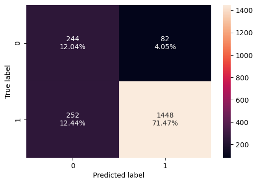

```python
# creating confusion matrix
confusion_matrix_sklearn(log_reg_over, X_val, Y_val)
```

## Observation

- Performance on the training set did not improve (actually performed worse) compared to the original logistic regression model training result.

#### Model 2 - Decision Tree on oversampled data

```python
# Fit the classifier on the resampled training data
d_tree.fit(X_train_over, Y_train_over)

# Predict on the t data
Y_pred = d_tree.predict(X_train_over)
```

#### Let's check the model performance on train and validation sets

```python
# Calculating different metrics on train set
d_tree_train_perf = model_performance_classification_sklearn(d_tree, X_train_over, Y_train_over)
print("Training performance:")
d_tree_train_perf
```

```
Training performance:
```

|  | Accuracy | Recall | Precision | F1 |
| --- | --- | --- | --- | --- |
| 0 | 1.000 | 1.000 | 1.000 | 1.000 |

```python
# Calculating different metrics on validattion set
d_tree_val_perf = model_performance_classification_sklearn(d_tree, X_val, Y_val)
print("Validation performance:")
d_tree_val_perf
```

```
Validation performance:
```

|  | Accuracy | Recall | Precision | F1 |
| --- | --- | --- | --- | --- |
| 0 | 0.923 | 0.948 | 0.961 | 0.954 |

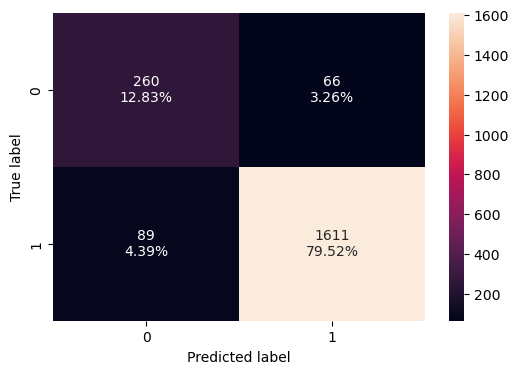

```python
# creating confusion matrix
confusion_matrix_sklearn(d_tree, X_val, Y_val)
```

## Observation

- Performance on the training and validation sets is similar to the original decision tree model training and validation results.

#### Model 3 - Bagging Classifier on oversampled data

```python
# Create a Bagging Classifier with SMOTE
bagging_classifier = BaggingClassifier(random_state=1)

# Fit the classifier on the resampled training data
bagging_classifier.fit(X_train_over, Y_train_over)
```

```
BaggingClassifier(random_state=1)
```

#### Let's check the model performance on train and validation sets

```python
# Calculating different metrics on train set
bagging_classifier_train_perf = model_performance_classification_sklearn(bagging_classifier, X_train_over, Y_train_over)
print("Training performance:")
bagging_classifier_train_perf
```

```
Training performance:
```

|  | Accuracy | Recall | Precision | F1 |
| --- | --- | --- | --- | --- |
| 0 | 0.997 | 0.995 | 0.999 | 0.997 |

```python
# Calculating different metrics on train set
bagging_classifier_val_perf = model_performance_classification_sklearn(bagging_classifier, X_val, Y_val)
print("Validation performance:")
bagging_classifier_val_perf
```

```
Validation performance:
```

|  | Accuracy | Recall | Precision | F1 |
| --- | --- | --- | --- | --- |
| 0 | 0.941 | 0.954 | 0.975 | 0.964 |

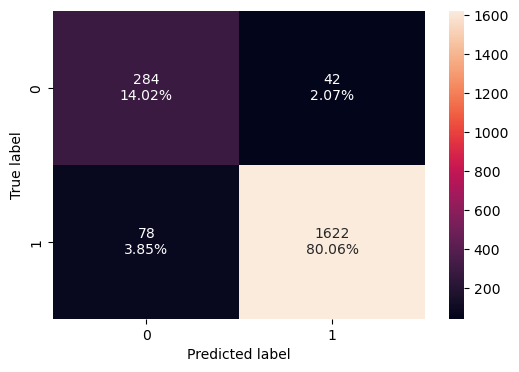

```python
# creating confusion matrix
confusion_matrix_sklearn(bagging_classifier, X_val, Y_val)
```

## Observation

- Performance on the bagging classifer oversampler is similar to the original bagging classifer model training result.

#### Model 4 - Random Forest on oversampled data

```python
# Create a Random Forest classifier
rf_classifier = RandomForestClassifier(random_state=1)

# Fit the classifier on the resampled training data
rf_classifier.fit(X_train_over, Y_train_over)
```

```
RandomForestClassifier(random_state=1)
```

#### Let's check the model performance on train and validation sets

```python
# Calculating different metrics on train set
rf_classifier_train_perf = model_performance_classification_sklearn(rf_classifier, X_train_over, Y_train_over)
print("Training performance:")
rf_classifier_train_perf
```

```
Training performance:
```

|  | Accuracy | Recall | Precision | F1 |
| --- | --- | --- | --- | --- |
| 0 | 1.000 | 1.000 | 1.000 | 1.000 |

```python
# Calculating different metrics on train set
rf_classifier_val_perf = model_performance_classification_sklearn(rf_classifier, X_val, Y_val)
print("Training performance:")
rf_classifier_val_perf
```

```
Training performance:
```

|  | Accuracy | Recall | Precision | F1 |
| --- | --- | --- | --- | --- |
| 0 | 0.946 | 0.972 | 0.964 | 0.968 |

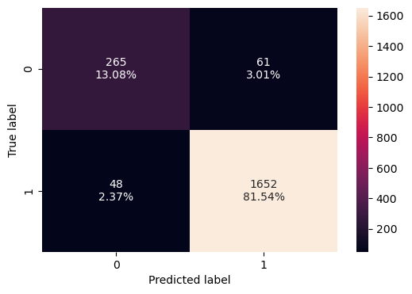

```python
# creating confusion matrix
confusion_matrix_sklearn(rf_classifier, X_val, Y_val)
```

## Observation

- Performance on the random forest classifer oversampler is similar to the original random forest classifer model training and validation results.

#### Model 5 - AdaBoost Classifier on oversampled data

```python
# Create an AdaBoost classifier
adaboost_classifier = AdaBoostClassifier(random_state=1)

# Fit the classifier on the resampled training data
adaboost_classifier.fit(X_train_over, Y_train_over)
```

```
AdaBoostClassifier(random_state=1)
```

#### Let's check the model performance on train and validation sets

```python
# Calculating different metrics on train set
adaboost_classifier_train_perf = model_performance_classification_sklearn(adaboost_classifier, X_train_over, Y_train_over)
print("Training performance:")
adaboost_classifier_train_perf
```

```
Training performance:
```

|  | Accuracy | Recall | Precision | F1 |
| --- | --- | --- | --- | --- |
| 0 | 0.965 | 0.963 | 0.968 | 0.965 |

```python
# Calculating different metrics on validation set
adaboost_classifier_val_perf = model_performance_classification_sklearn(adaboost_classifier, X_val, Y_val)
print("Validation performance:")
adaboost_classifier_val_perf
```

```
Validation performance:
```

|  | Accuracy | Recall | Precision | F1 |
| --- | --- | --- | --- | --- |
| 0 | 0.941 | 0.954 | 0.975 | 0.964 |

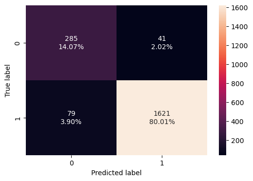

```python
# creating confusion matrix
confusion_matrix_sklearn(adaboost_classifier, X_val, Y_val)
```

## Observation

- Performance on the adaboost classifer oversampler is slightly worse than the original random forest classifer model training and validation results.

#### Model 6 - Gradient Boosting Classifier on oversampled data

```python
# Create a Gradient Boosting classifier
gb_classifier = GradientBoostingClassifier(random_state=1)

# Fit the classifier on the resampled training data
gb_classifier.fit(X_train_over, Y_train_over)
```

```
GradientBoostingClassifier(random_state=1)
```

#### Let's check the model performance on train and validation sets

```python
# Calculating different metrics on train set
gb_classifier_train_perf = model_performance_classification_sklearn(gb_classifier, X_train_over, Y_train_over)
print("Training performance:")
gb_classifier_train_perf
```

```
Training performance:
```

|  | Accuracy | Recall | Precision | F1 |
| --- | --- | --- | --- | --- |
| 0 | 0.979 | 0.976 | 0.982 | 0.979 |

```python
# Calculating different metrics on validation set
gb_classifier_val_perf = model_performance_classification_sklearn(gb_classifier, X_val, Y_val)
print("Validation performance:")
gb_classifier_val_perf
```

```
Validation performance:
```

|  | Accuracy | Recall | Precision | F1 |
| --- | --- | --- | --- | --- |
| 0 | 0.959 | 0.975 | 0.976 | 0.976 |

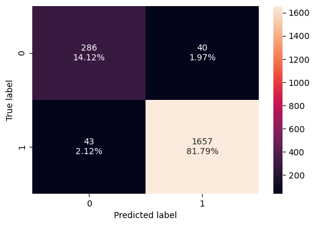

```python
# creating confusion matrix
confusion_matrix_sklearn(gb_classifier, X_val, Y_val)
```

## Observation

- Performance on the gradient boosting classifer oversampler is similar to the original gradient boosting classifer model training and validation results.

### Model Building with Undersampled data

```python
# Random undersampler for under sampling the data
rus = RandomUnderSampler(random_state=1, sampling_strategy=1)
X_train_un, Y_train_un = rus.fit_resample(X_train, Y_train)
```

```python
print("Before Undersampling, counts of label 'Yes': {}".format(sum(Y_train == 1)))
print("Before Undersampling, counts of label 'No': {} \n".format(sum(Y_train == 0)))

print("After Undersampling, counts of label 'Yes': {}".format(sum(Y_train_un == 1)))
print("After Undersampling, counts of label 'No': {} \n".format(sum(Y_train_un == 0)))

print("After Undersampling, the shape of train_X: {}".format(X_train_un.shape))
print("After Undersampling, the shape of train_Y: {} \n".format(Y_train_un.shape))
```

```
Before Undersampling, counts of label 'Yes': 5099
Before Undersampling, counts of label 'No': 976

After Undersampling, counts of label 'Yes': 976
After Undersampling, counts of label 'No': 976

After Undersampling, the shape of train_X: (1952, 29)
After Undersampling, the shape of train_Y: (1952,)
```

#### Model 1 - Logistic Regression on undersampled data

```python
log_reg_under = LogisticRegression(random_state=1)
log_reg_under.fit(X_train_un, Y_train_un)
```

```
LogisticRegression(random_state=1)
```

#### Let's check the model performance on train and validation set

```python
# Calculating different metrics on train set
log_reg_under_train_perf = model_performance_classification_sklearn(
    log_reg_under, X_train_un, Y_train_un
)
print("Training performance:")
log_reg_under_train_perf
```

```
Training performance:
```

|  | Accuracy | Recall | Precision | F1 |
| --- | --- | --- | --- | --- |
| 0 | 0.788 | 0.790 | 0.787 | 0.788 |

```python
# Calculating different metrics on validation set
log_reg_under_val_perf = model_performance_classification_sklearn(
    log_reg_under, X_val, Y_val
)
print("Validation performance:")
log_reg_under_val_perf
```

```
Validation performance:
```

|  | Accuracy | Recall | Precision | F1 |
| --- | --- | --- | --- | --- |
| 0 | 0.800 | 0.808 | 0.946 | 0.872 |

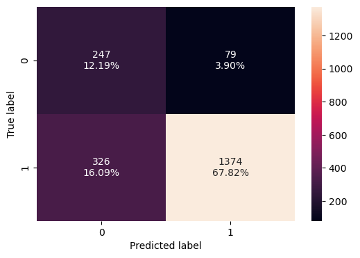

```python
# creating confusion matrix
confusion_matrix_sklearn(log_reg_under, X_val, Y_val)
```